# Homework 2

Allan Kimaina

February 22, 2018

# Question 1

## a. Using the wine data from the previous homework, create two new variables by logarithmically transforming both wine and mortality

## b. Plot mortality vs. wine; log mortality vs. wine, mortality vs. log wine and log mortality vs. log wine. Which one looks more linear?

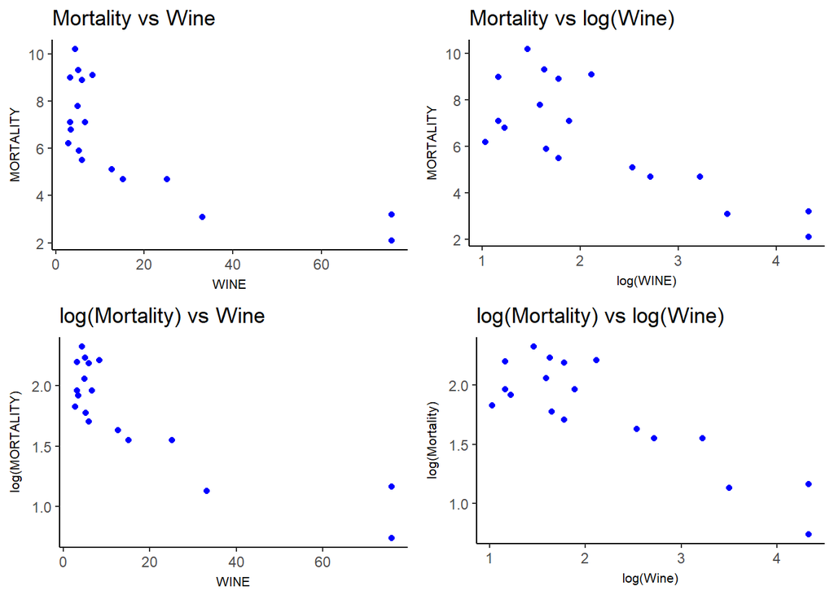

- From the above scatter plot, the logarithmic transformation of both dependent variable (log of Mortality) and independent varaible (log of Wine) result to the most linear relationship compared to the other plots.
- Transforming both predictor and response variable we get the best linear relationship

## c. Fit four linear regression models corresponding to the four plots and report the regression equation and R-squared. Which model do you think is best?

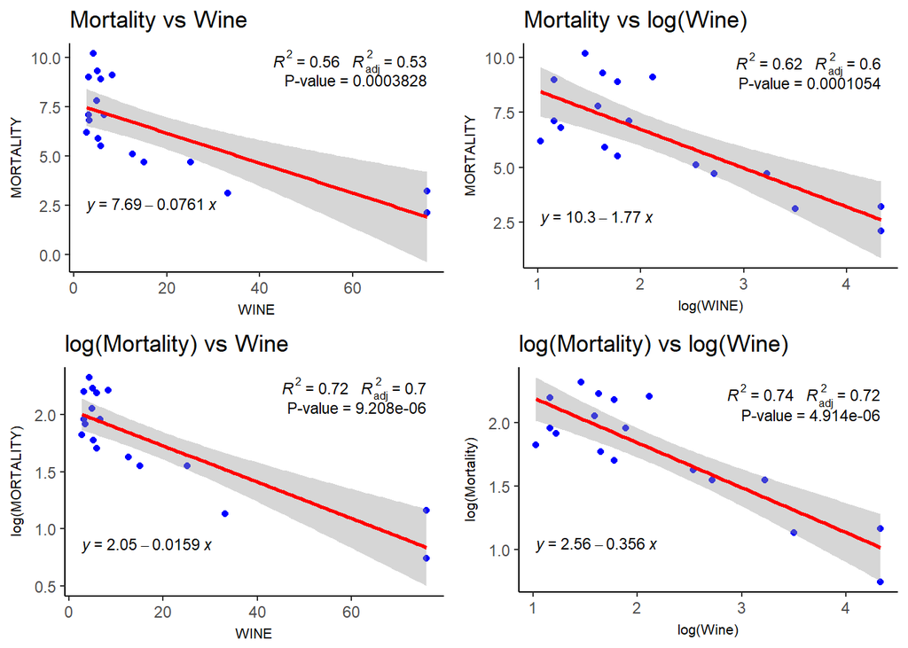

Graphically we can notice that the regression line for the log transformed model (ln(y) ~ ln(x)) covers most data-points as well as having a more precise and uniform CI band compared with the other 3 models.

For these reasons, **the best fit model** is ln(y)~ln(x) model because it has the highest explanatory model compared to the other models. Furthermore, it has a p-value that is very significant (approximately 4.914e-06)

### Model Diagnostics

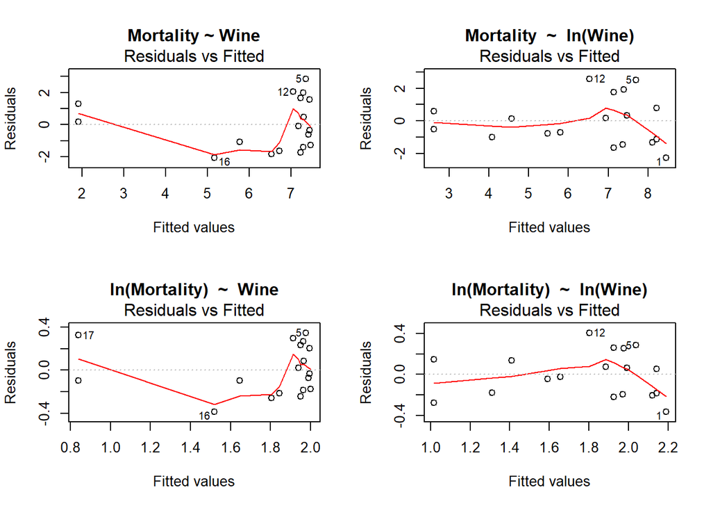

Looking at the residual plots, ln(Mortality) ~ ln(Wine) model exhibits acceptable randomness and unpredictability. From the plot, the residuals bounce randomly around the 0 line and roughly forms a horizontal band around the 0 line without any noticeable pattern. This suggests that the variances of the error terms are approximately equal.

The other models seem not to follow the rule of residual heteroskedasticity which is a crucial component of any regression model. Residuals in the other models deviate from linearity and equality of standard deviations assumptions. Hence this gives us more reason to select the model with logarithmic transformation of both predictor and response as the best fit model

### Conclusion

In summary, the model with the natural log of heartAttackMortality as the response and the natural log of wineConsumption as the predictor exhibits a relationship with the highest explanatory power. This relationship appears to be linear and at the same time with error terms that appear independent and normally distributed with somewhat equal variances. Therefore we have sufficient evidence that this model [ln(y)~ln(x)] is the best.

## d. Interpret each regression model by describing the change in mortality for a given change in the predictor. Use an increase of 10 units of wine consumption for linear wine and a doubling of wine consumption for logarithmic wine

### Mortality vs Wine

- An increase of wine consumption by 10 Liters per person will decrease Ischemic heart attack mortality by 0.761

### Mortality vs log(Wine)

- Doubling wine consumption will decrease Ischemic heart attack mortality by 1.227

### log(Mortality) vs Wine

- An increase of wine consumption by 10 Liters per person will decrease Ischemic heart attack mortality by a median proportion of 0.8529964
- An increase of wine consumption by 10 Liters per person will decrease Ischemic heart attack mortality by 14.7%

### log(Mortality) vs log(Wine)

- Doubling wine consumption will decrease Ischemic heart attack mortality by 21.85%

# Question 2: The Dramatic U.S. Presidential Election of 2000

The U.S. presidential election of November 7, 2000 was one of the closest in history. As returns were counted on election night it became clear that the outcome in the state of Florida would determine the next president. At one point in the evening, television networks projected that the state was carried by the Democratic nominee, Al Gore, but a retraction of the projection followed a few hours later. Then, early in the morning of November 8, the networks projected that the Republican nominee, George W. Bush, had carried Florida and won the presidency. Gore called Bush to concede. While on route to his concession speech, though, the Florida count changed rapidly in his favor. The networks once again reversed their projection, and Gore called Bush to retract his concession. When the roughly 6 million Florida votes had been counted, Bush was shown to be leading by only 1,738, and the narrow margin triggered an automatic recount. The recount, completed in the evening of November 9, showed Bush’s lead to be less than 400. Meanwhile, angry Democratic voters in Palm Beach County complained that a confusing “butterfly” lay-out ballot caused them to accidentally vote for the Reform Party candidate Pat Buchanan instead of Gore. The ballot, as illustrated in Display 8.23, listed presidential candidates on both a left-hand and a right-hand page. Voters were to register their vote by punching the circle corresponding to their choice, from the column of circles between the pages. It was suspected that since Bush’s name was listed first on the left-hand page, Bush voters likely selected the first circle. Since Gore’s name was listed second on the left-hand side, many voters, who already knew who they wished to vote for, did not bother examining the right-handed side and consequently selected the second circle in the column; the one actually corresponding to Buchanan. Two pieces of evidence supported this claim: Buchanan had an unusually high percentage of the vote in that county, and an unusually large number of ballots (19,000) were discarded because voters had marked two circles (possibly by inadvertently voting for Buchanan and then trying to correct the mistake by then voting for Gore).

## a. The data in File Bush.xls contain the numbers of votes for Buchanan and Bush in all 67 counties in Florida. What evidence is there in the scatterplot of Display 8.25 that Buchanan received more votes than expected in Palm Beach County? Analyze the data without Palm Beach County results to obtain an equation for predicting Buchanan votes from Bush votes. Obtain a 95% prediction interval for the number of Buchanan votes in Palm Beach from this result-assuming the relationship is the same in this county as in the others. If it is assumed that Buchanan’s actual count contains a number of votes intended for Gore, what can be said about the likely size of this number from the prediction interval? (Consider transformation.)

```
##
## Call:
## lm(formula = buchanan2000 ~ bush2000, data = bush.withoutPalmBeach)
##
## Residuals:
##     Min      1Q  Median      3Q     Max
## -512.43  -47.97  -17.09   41.78  305.45
##
## Coefficients:
##              Estimate Std. Error t value Pr(>|t|)
## (Intercept) 6.557e+01  1.733e+01   3.784 0.000343 ***
## bush2000    3.482e-03  2.501e-04  13.923  < 2e-16 ***
## ---
## Signif. codes:  0 '***' 0.001 '**' 0.01 '*' 0.05 '.' 0.1 ' ' 1
##
## Residual standard error: 112.5 on 64 degrees of freedom
## Multiple R-squared:  0.7518, Adjusted R-squared:  0.7479
## F-statistic: 193.8 on 1 and 64 DF,  p-value: < 2.2e-16
```

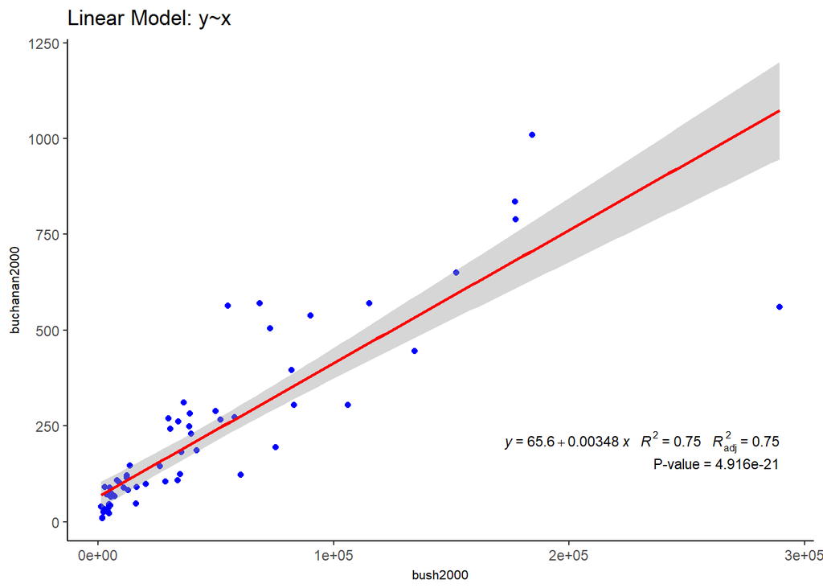

```
##        fit     lwr      upr
## 1 597.7677 364.709 830.8264
```

## b. One might suspect that the prediction interval can be narrowed and the validity of the procedure strengthened by incorporating other relevant predictor variables. The dataset gives the vote counts by county in Florida for Buchanan and for four other presidential candidates in 2000, along with the total vote counts in 2000, the presidential vote counts for three presidential candidates in 1996, the vote count for Buchanan in his only other campaign in Florida, the 1996 Republican primary, the registration in Buchanan’s Reform party, and the total political party registration in the county.

Analyze the data in Ex1222 and write a statistical summary predicting the number of Buchanan, votes in Palm Beach Country that were not intended for him. It would be appropriate to describe any unverifiable assumptions used in applying the prediction equation for this purpose. (Suggestion: Find a model for predicting Buchanan’s 2000 vote from other variables, excluding Palm Beach County, which is listed last in the data set. Consider a transformation of all counts.)

```
##
## Call:
## lm(formula = buchanan2000 ~ bush2000 + gore2000 + nader2000 +
##     browne2000 + total2000 + clinton96 + dole96 + perot96 + buchanan96p +
##     reform.reg + total.reg, data = bush.withoutPalmBeach)
##
## Residuals:
##      Min       1Q   Median       3Q      Max
## -170.164  -27.398   -8.144   30.685  201.413
##
## Coefficients: (1 not defined because of singularities)
##               Estimate Std. Error t value Pr(>|t|)
## (Intercept) 28.9408823 13.0088300   2.225   0.0302 *
## bush2000    -0.0001805  0.0014051  -0.128   0.8982
## gore2000     0.0001560  0.0015165   0.103   0.9184
## nader2000    0.0425298  0.0181342   2.345   0.0226 *
## browne2000   0.0368462  0.0312207   1.180   0.2430
## total2000           NA         NA      NA       NA
## clinton96   -0.0019359  0.0019588  -0.988   0.3273
## dole96       0.0030641  0.0022621   1.355   0.1811
## perot96      0.0137108  0.0061365   2.234   0.0295 *
## buchanan96p -0.0220004  0.0134945  -1.630   0.1087
## reform.reg   0.5391845  0.3924711   1.374   0.1751
## total.reg    0.0000253  0.0002552   0.099   0.9214
## ---
## Signif. codes:  0 '***' 0.001 '**' 0.01 '*' 0.05 '.' 0.1 ' ' 1
##
## Residual standard error: 73.76 on 55 degrees of freedom
## Multiple R-squared:  0.9082, Adjusted R-squared:  0.8916
## F-statistic: 54.44 on 10 and 55 DF,  p-value: < 2.2e-16
```

```
## Start:  AIC=577.67
## buchanan2000 ~ bush2000 + gore2000 + nader2000 + browne2000 +
##     total2000 + clinton96 + dole96 + perot96 + buchanan96p +
##     reform.reg + total.reg
##
##
## Step:  AIC=577.67
## buchanan2000 ~ bush2000 + gore2000 + nader2000 + browne2000 +
##     clinton96 + dole96 + perot96 + buchanan96p + reform.reg +
##     total.reg
##
##               Df Sum of Sq    RSS    AIC
## - total.reg    1      53.5 299248 575.68
## - gore2000     1      57.6 299252 575.68
## - bush2000     1      89.8 299285 575.69
## - clinton96    1    5313.0 304508 576.83
## - browne2000   1    7576.9 306772 577.32
## <none>                     299195 577.67
## - dole96       1    9981.5 309176 577.83
## - reform.reg   1   10267.2 309462 577.89
## - buchanan96p  1   14459.0 313654 578.78
## - perot96      1   27156.8 326352 581.40
## - nader2000    1   29921.6 329116 581.96
##
## Step:  AIC=575.68
## buchanan2000 ~ bush2000 + gore2000 + nader2000 + browne2000 +
##     clinton96 + dole96 + perot96 + buchanan96p + reform.reg
##
##               Df Sum of Sq    RSS    AIC
## - bush2000     1        53 299301 573.69
## - gore2000     1        59 299308 573.69
## - clinton96    1      5378 304627 574.85
## - browne2000   1      7773 307021 575.37
## <none>                     299248 575.68
## - dole96       1     10177 309425 575.89
## - buchanan96p  1     14630 313879 576.83
## + total.reg    1        53 299195 577.67
## - perot96      1     27140 326389 579.41
## - nader2000    1     34668 333917 580.91
## - reform.reg   1     65864 365112 586.81
```

[output cut: 21 more lines]

```
##     perot96 + buchanan96p + reform.reg
##
##               Df Sum of Sq    RSS    AIC
## <none>                     299316 571.69
## - browne2000   1      9307 308623 571.71
## - buchanan96p  1     16213 315530 573.18
## + total.reg    1        26 299290 573.69
## + gore2000     1        15 299301 573.69
## + bush2000     1         9 299308 573.69
## + total2000    1         0 299316 573.69
## - perot96      1     32428 331744 576.48
## - nader2000    1     56147 355464 581.04
## - clinton96    1     63714 363031 582.43
## - dole96       1     64239 363556 582.53
## - reform.reg   1     70495 369811 583.65
```

```
## Stepwise Model Path
## Analysis of Deviance Table
##
## Initial Model:
## buchanan2000 ~ bush2000 + gore2000 + nader2000 + browne2000 +
##     total2000 + clinton96 + dole96 + perot96 + buchanan96p +
##     reform.reg + total.reg
##
## Final Model:
## buchanan2000 ~ nader2000 + browne2000 + clinton96 + dole96 +
##     perot96 + buchanan96p + reform.reg
##
##
##          Step Df Deviance Resid. Df Resid. Dev      AIC
## 1                                55   299194.8 577.6669
## 2 - total2000  0  0.00000        55   299194.8 577.6669
## 3 - total.reg  1 53.45126        56   299248.3 575.6787
## 4  - bush2000  1 53.23473        57   299301.5 573.6904
## 5  - gore2000  1 14.92698        58   299316.4 571.6937
```

```
##
## Call:
## lm(formula = buchanan2000 ~ nader2000 + browne2000 + clinton96 +
##     dole96 + perot96 + buchanan96p + reform.reg, data = bush.withoutPalmBeach)
##
## Residuals:
##      Min       1Q   Median       3Q      Max
## -167.575  -28.074   -8.226   30.929  201.016
##
## Coefficients:
##               Estimate Std. Error t value Pr(>|t|)
## (Intercept) 28.8290080 12.3015063   2.344 0.022551 *
## nader2000    0.0419337  0.0127130   3.298 0.001664 **
## browne2000   0.0366111  0.0272620   1.343 0.184525
## clinton96   -0.0017008  0.0004840  -3.514 0.000864 ***
## dole96       0.0027898  0.0007907   3.528 0.000826 ***
## perot96      0.0137042  0.0054670   2.507 0.015010 *
## buchanan96p -0.0215172  0.0121395  -1.772 0.081565 .
## reform.reg   0.5745946  0.1554658   3.696 0.000487 ***
## ---
## Signif. codes:  0 '***' 0.001 '**' 0.01 '*' 0.05 '.' 0.1 ' ' 1
##
## Residual standard error: 71.84 on 58 degrees of freedom
## Multiple R-squared:  0.9082, Adjusted R-squared:  0.8971
## F-statistic: 81.97 on 7 and 58 DF,  p-value: < 2.2e-16
```

# Question 3

### a. Compute “Jittered” versions of-treatment, days after inoculation, and an indicator variable for females by adding small random numbers to each (uniform random numbers between -.15 and .15 work well). Or you could use the jitter function.

```
##    BRAIN   LIVER TIME TREAT DAYS SEX WEIGHT LOSS TUMOR      RATIO
## 1  41081 1456164  0.5    BD   10   F    239  5.9   221 0.02821179
## 2  44286 1602171  0.5    BD   10   F    225  4.0   246 0.02764124
## 3 102926 1601936  0.5    BD   10   F    224 -4.9    61 0.06425101
## 4  25927 1776411  0.5    BD   10   F    184  9.8   168 0.01459516
## 5  42643 1351184  0.5    BD   10   F    250  6.0   164 0.03155973
## 6  31342 1790863  0.5    NS   10   F    196  7.7   260 0.01750106
##   isTreatJitter daysJitter femaleJitter log_RATIO   log_Time
## 1    1.13293917  10.060979    1.1108712 -3.568015 -0.6931472
## 2    1.01238234   9.926778    1.1035670 -3.588446 -0.6931472
## 3    1.12591227  10.149614    0.9814812 -2.744958 -0.6931472
## 4    1.06288800   9.962071    0.9880138 -4.227065 -0.6931472
## 5    1.05734668   9.987960    0.9693537 -3.455873 -0.6931472
## 6    0.08547134   9.998793    0.9301830 -4.045494 -0.6931472
```

### b. Obtain a matrix of scatter plots for the following variables: log sacrifice time, treatment (jittered), days after inoculation (jittered), sex (jittered), and the log of the brain tumor-to-liver antibody ratio. Use the function pairs in the graphics package or scatterplotMatrix in the car package.

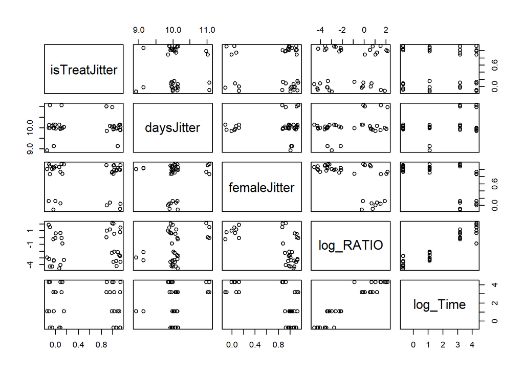

### c. Obtain a matrix of the correlation coefficients among the same five variables (not jittered).

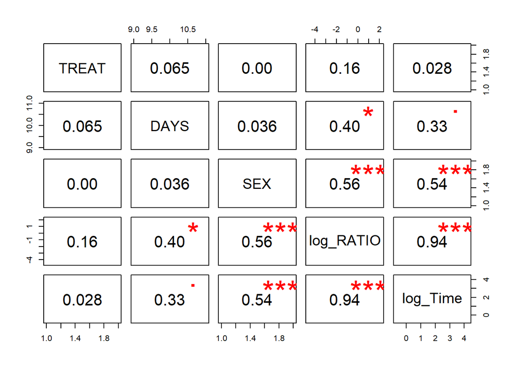

[output not shown]

[output not shown]

## 1 0.5 BD -3.5048856 -4.6655725 -2.344199

## 2 3 BD -2.3707373 -3.5381356 -1.203339

## 3 24 BD 0.7523685 -0.4185564 1.923293

## 4 72 BD 1.6489790 0.4780541 2.819904

## 5 0.5 NS -4.3016813 -5.4690795 -3.134283

## 6 3 NS -3.1675330 -4.3282199 -2.006846

[output not shown]

## Call:

## lm(formula = log_RATIO ~ TREAT + as.factor(TIME) + SEX + WEIGHT +

## DAYS + LOSS + TUMOR, data = bloodBrain)

## Residuals:

## Min 1Q Median 3Q Max

## -1.58034 -0.20482 -0.04134 0.17296 0.96182

## Coefficients:

## Estimate Std. Error t value Pr(>|t|)

## (Intercept) -4.063527 3.144780 -1.292 0.208609

[output not shown]